# Module 4 Code Along: Hotel bookings

Nicholas Duran, Derek Powell, Jessica Kosie[^1]

Mine Çetinkaya-Rundel[^2]

15 September, 2026

```r
library(tidyverse)
```

### Understanding where our data comes from

We will continue working with the dataset used in last week’s code-along. If you remember, this from the “R For Data Science” community podcast called Tidy Tuesday. The dataset is called “Hotel Bookings:” Learn more [here](https://github.com/rfordatascience/tidytuesday/blob/master/data/2020/2020-02-11/readme.md)

```r
hotels <- read_csv("https://raw.githubusercontent.com/rfordatascience/tidytuesday/master/data/2020/2020-02-11/hotels.csv")
```

Let’s visualize different aspects of hotel bookings on a few different timescales.

## Plot average daily rate (`adr`) by month

### Exercise 1. Plot average `adr` by arrival month for each hotel type.

What are the steps do I need to take to solve this problem? Why not write some pseudocode?

What would be a good way to plot change over time?

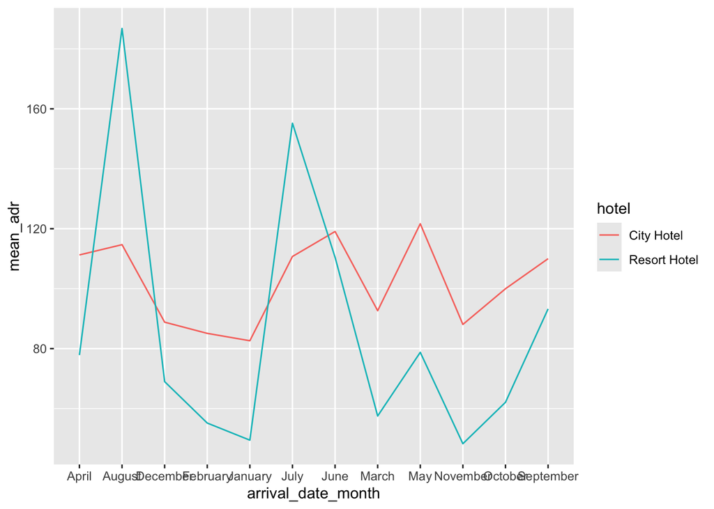

```r
# We want to plot the average `adr` by hotel type and month. So, how do we do that?
# group the data by hotel type and month
# calculate the mean adr for each combination of hotel type and month
# what would be a good way to plot change over time?
# create a line graph where we can look at how the price changes across months - line graphs are good for plotting change over time
# use the line color to indicate hotel type

hotels %>%
  group_by(hotel, arrival_date_month)  %>%
  summarise(mean_adr = mean(adr)) %>%
  ggplot(aes(x=arrival_date_month, y=mean_adr, group=hotel, color=hotel)) +
    geom_line()
```

```r
# what's wrong with this graph?
```

### Exercise 2. Fix ordering of the months (as factors)

We will want to use a function from the **forcats** package, see https://forcats.tidyverse.org/reference/index.html for inspiration and help.

```r
# check out the arrival_date_month variable

levels(hotels$arrival_date_month)
```

```r
class(hotels$arrival_date_month)
```

```
## [1] "character"
```

```r
# or look at tibble
hotels
```

```
## # A tibble: 119,390 × 32
##    hotel        is_canceled lead_time arrival_date_year arrival_date_month
##    <chr>              <dbl>     <dbl>             <dbl> <chr>
##  1 Resort Hotel           0       342              2015 July
##  2 Resort Hotel           0       737              2015 July
##  3 Resort Hotel           0         7              2015 July
##  4 Resort Hotel           0        13              2015 July
##  5 Resort Hotel           0        14              2015 July
##  6 Resort Hotel           0        14              2015 July
##  7 Resort Hotel           0         0              2015 July
##  8 Resort Hotel           0         9              2015 July
##  9 Resort Hotel           1        85              2015 July
## 10 Resort Hotel           1        75              2015 July
## # ℹ 119,380 more rows
## # ℹ 27 more variables: arrival_date_week_number <dbl>,
## #   arrival_date_day_of_month <dbl>, stays_in_weekend_nights <dbl>,
## #   stays_in_week_nights <dbl>, adults <dbl>, children <dbl>, babies <dbl>,
## #   meal <chr>, country <chr>, market_segment <chr>,
## #   distribution_channel <chr>, is_repeated_guest <dbl>,
## #   previous_cancellations <dbl>, previous_bookings_not_canceled <dbl>, …
```

```r
# need to change it into a factor

hotels <- hotels %>%
  mutate(arrival_date_month_fct = fct_relevel(arrival_date_month, c("January", "February", "March", "April", "May", "June", "July", "August", "September", "October", "November", "December")))

# now, let's look at the class and levels

class(hotels$arrival_date_month_fct)
```

```
## [1] "factor"
```

```r
levels(hotels$arrival_date_month_fct)
```

```
##  [1] "January"   "February"  "March"     "April"     "May"       "June"
##  [7] "July"      "August"    "September" "October"   "November"  "December"
```

```r
# R has some useful built-in constants, like `pi`, letters, LETTERS, month.name
hotels_v2 <- hotels %>%
  mutate(arrival_date_month_fct = fct_relevel(arrival_date_month, month.name))

# now, let's look at the class and levels

class(hotels_v2$arrival_date_month_fct)
```

```
## [1] "factor"
```

```r
levels(hotels_v2$arrival_date_month_fct)
```

```
##  [1] "January"   "February"  "March"     "April"     "May"       "June"
##  [7] "July"      "August"    "September" "October"   "November"  "December"
```

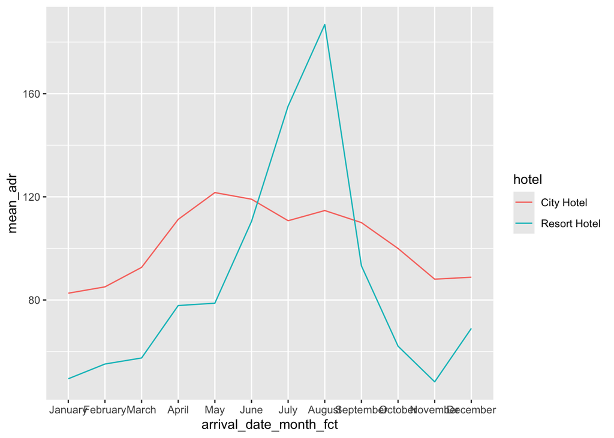

```r
# now recreate your plot
hotels_v2 %>%
  group_by(hotel, arrival_date_month_fct) %>%
  summarise(mean_adr = mean(adr)) %>%
  ggplot(aes(x=arrival_date_month_fct, y=mean_adr, group=hotel, color=hotel)) +
    geom_line()
```

```r
# look at the x axis -- much better! but still not the most attractive plot.
```

### Exercise 3. Make it pretty

Totally up to you how to do this. Go wild.

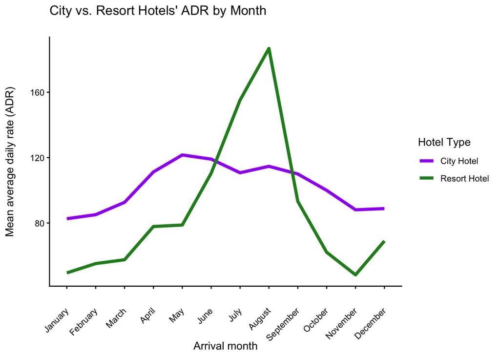

```r
# take ~10min with folks around you, try to make the plot pretty (labels, colors, theme)

hotels %>%
  group_by(hotel, arrival_date_month_fct) %>%
  summarise(mean_adr = mean(adr)) %>%
  ggplot(
    aes(x=arrival_date_month_fct,
        y=mean_adr,
        group=hotel,
        color=hotel)
    ) +
    geom_line(linewidth = 1.5) +
  theme_classic() +
  theme(axis.text.x = element_text(angle = 45, vjust = 0.5, hjust = 1)) +
  labs(
    x = "\nArrival month",
    y = "Mean average daily rate (ADR)\n",
    title = "City vs. Resort Hotels' ADR by Month\n",
    color = "Hotel Type"
  ) +
  scale_color_manual(values = c("purple", "forestgreen"))
```

**A final touch:** Change the y-axis label so the values are shown with dollar signs, e.g. $80 instead of 80.

We can use the `dollar_format()` function from the **scales** package, see https://scales.r-lib.org/reference/index.html.

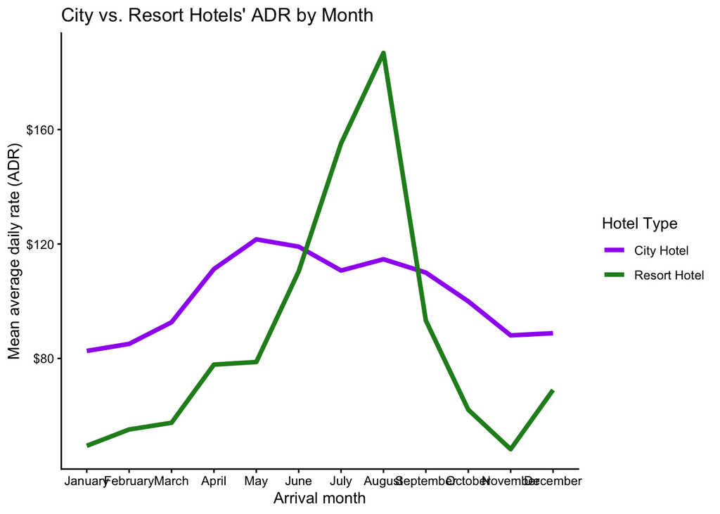

```r
#copy and paste code and add dollar formatting

hotels %>%
  group_by(hotel, arrival_date_month_fct) %>%
  summarise(mean_adr = mean(adr)) %>%
  ggplot(
    aes(x=arrival_date_month_fct,
        y=mean_adr,
        group=hotel,
        color=hotel)
    ) +
    geom_line(linewidth = 1.5) +
  theme_classic() +
  labs(
    x = "Arrival month",
    y = "Mean average daily rate (ADR)",
    title = "City vs. Resort Hotels' ADR by Month",
    color = "Hotel Type"
  ) +
  scale_color_manual(values = c("purple", "forestgreen")) +
  scale_y_continuous(labels = scales::dollar_format())
```

## Plot cancellations by day of week

### Exercise 4. Are travelers arriving different days (Sunday through Saturday) more likely to cancel their plans?

uh oh, no day of the week variable! we can use **lubridate** for this

```r
library(lubridate)

hotels <- hotels %>%
  mutate(
    arrival_date_str = paste(arrival_date_month, arrival_date_day_of_month, arrival_date_year),
    arrival_date_mdy = parse_date_time(arrival_date_str, "mdy")
  )

hotels %>%
  select(arrival_date_month, arrival_date_day_of_month, arrival_date_year, arrival_date_str, arrival_date_mdy)
```

```
## # A tibble: 119,390 × 5
##    arrival_date_month arrival_date_day_of_m…¹ arrival_date_year arrival_date_str
##    <chr>                                <dbl>             <dbl> <chr>
##  1 July                                     1              2015 July 1 2015
##  2 July                                     1              2015 July 1 2015
##  3 July                                     1              2015 July 1 2015
##  4 July                                     1              2015 July 1 2015
##  5 July                                     1              2015 July 1 2015
##  6 July                                     1              2015 July 1 2015
##  7 July                                     1              2015 July 1 2015
##  8 July                                     1              2015 July 1 2015
##  9 July                                     1              2015 July 1 2015
## 10 July                                     1              2015 July 1 2015
## # ℹ 119,380 more rows
## # ℹ abbreviated name: ¹arrival_date_day_of_month
## # ℹ 1 more variable: arrival_date_mdy <dttm>
```

```r
hotels %>%
  select(starts_with("arrival"))
```

```
## # A tibble: 119,390 × 7
##    arrival_date_year arrival_date_month arrival_date_week_number
##                <dbl> <chr>                                 <dbl>
##  1              2015 July                                     27
##  2              2015 July                                     27
##  3              2015 July                                     27
##  4              2015 July                                     27
##  5              2015 July                                     27
##  6              2015 July                                     27
##  7              2015 July                                     27
##  8              2015 July                                     27
##  9              2015 July                                     27
## 10              2015 July                                     27
## # ℹ 119,380 more rows
## # ℹ 4 more variables: arrival_date_day_of_month <dbl>,
## #   arrival_date_month_fct <fct>, arrival_date_str <chr>,
## #   arrival_date_mdy <dttm>
```

```r
days_of_week <- c("Sunday","Monday","Tuesday","Wednesday","Thursday","Friday","Saturday")

hotels <- hotels %>%
  mutate(
    arrival_date_weekday_number = wday(arrival_date_mdy),
    arrival_date_weekday = factor(arrival_date_weekday_number, labels=days_of_week)
  )

hotels %>%
  select(arrival_date_mdy, arrival_date_weekday_number, arrival_date_weekday)
```

```
## # A tibble: 119,390 × 3
##    arrival_date_mdy    arrival_date_weekday_number arrival_date_weekday
##    <dttm>                                    <dbl> <fct>
##  1 2015-07-01 00:00:00                           4 Wednesday
##  2 2015-07-01 00:00:00                           4 Wednesday
##  3 2015-07-01 00:00:00                           4 Wednesday
##  4 2015-07-01 00:00:00                           4 Wednesday
##  5 2015-07-01 00:00:00                           4 Wednesday
##  6 2015-07-01 00:00:00                           4 Wednesday
##  7 2015-07-01 00:00:00                           4 Wednesday
##  8 2015-07-01 00:00:00                           4 Wednesday
##  9 2015-07-01 00:00:00                           4 Wednesday
## 10 2015-07-01 00:00:00                           4 Wednesday
## # ℹ 119,380 more rows
```

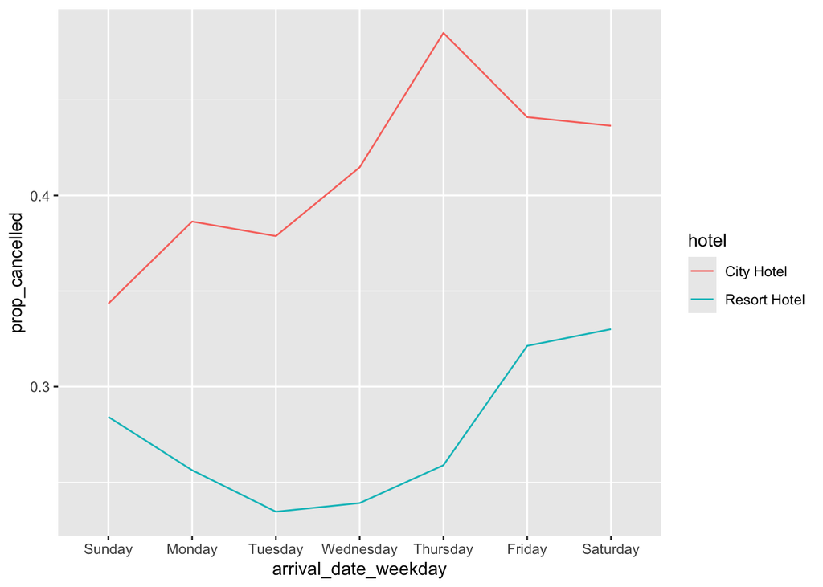

```r
hotels %>%
  group_by(hotel, arrival_date_weekday) %>%
  summarize(mean_adr = mean(adr),
            n = n(),
            prop_cancelled = sum(is_canceled)/n()) %>%
  ggplot(aes(x=arrival_date_weekday, y=prop_cancelled, color=hotel, group=hotel)) +
  geom_line()
```

What do you see from this graph?

Add a title and sub-title that describe what you’ve found.

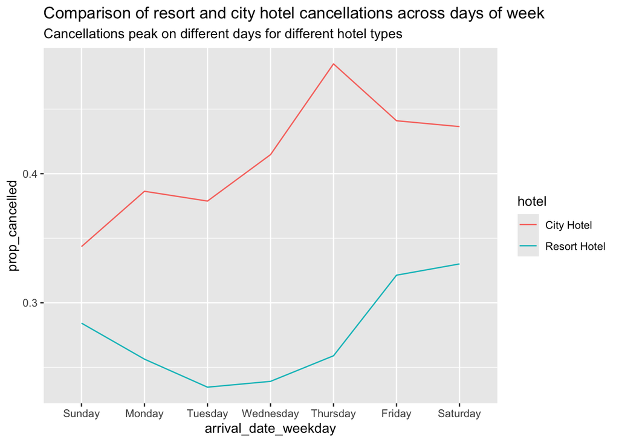

```r
hotels %>%
  group_by(hotel, arrival_date_weekday) %>%
  summarize(mean_adr = mean(adr),
            n = n(),
            prop_cancelled = sum(is_canceled)/n()) %>%
  ggplot(aes(x=arrival_date_weekday, y=prop_cancelled, color=hotel, group=hotel)) +
  geom_line() +
  labs(
    title = "Comparison of resort and city hotel cancellations across days of week",
    subtitle = "Cancellations peak on different days for different hotel types"
  )
```

[^1]: Authored modifications to original code
[^2]: Original author of exercise